# ADSP 31006 Time Series Analysis and Forecasting

### Question 2:

Plot the training dataset. Is the Box-Cox transformation necessary for this data? Why?

Ans:

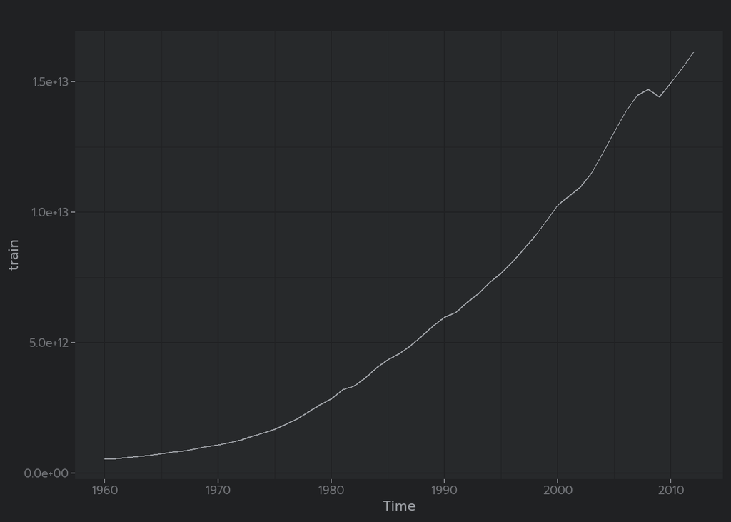

```r
autoplot(train)
```

To find if box cox transformation is necessary we should first find the lambda value.

```r
lambda <- BoxCox.lambda(train)
lambda
```

```
## [1] 0.2310656
```

As the lambda value is not 1, we should use box cox transformation.

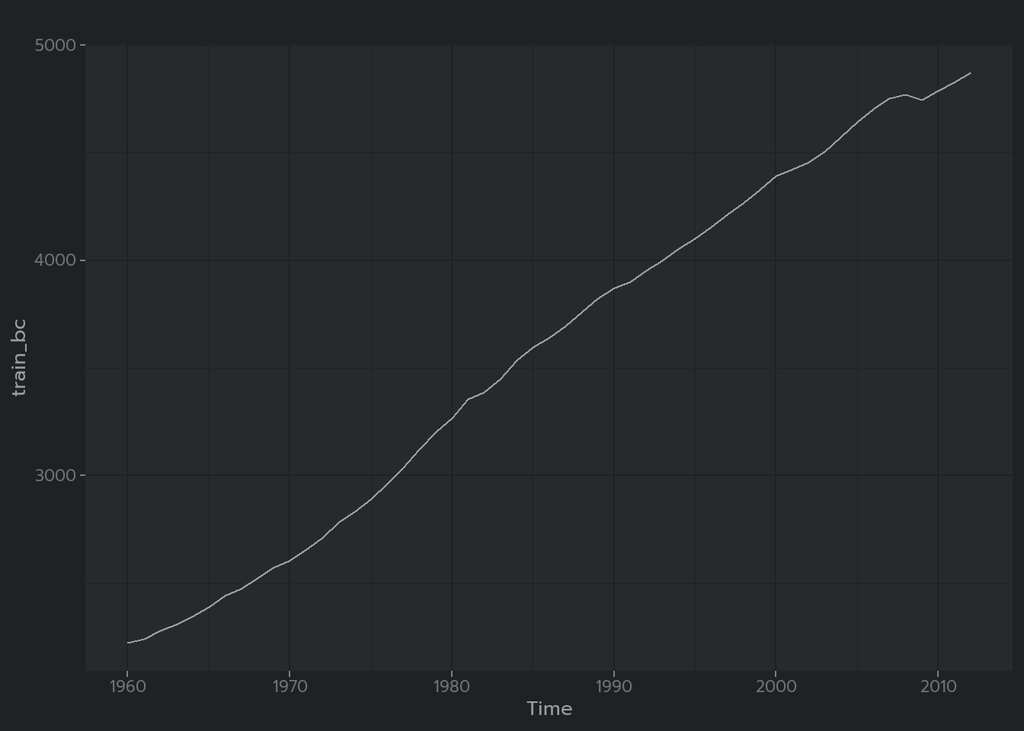

```r
train_bc <- BoxCox(train, lambda = lambda)
autoplot(train_bc)
```

### Question 3:

Plot the 1st and 2nd order difference of the data. Apply KPSS Test for Stationarity to determine which difference order results in a stationary dataset.

Ans:

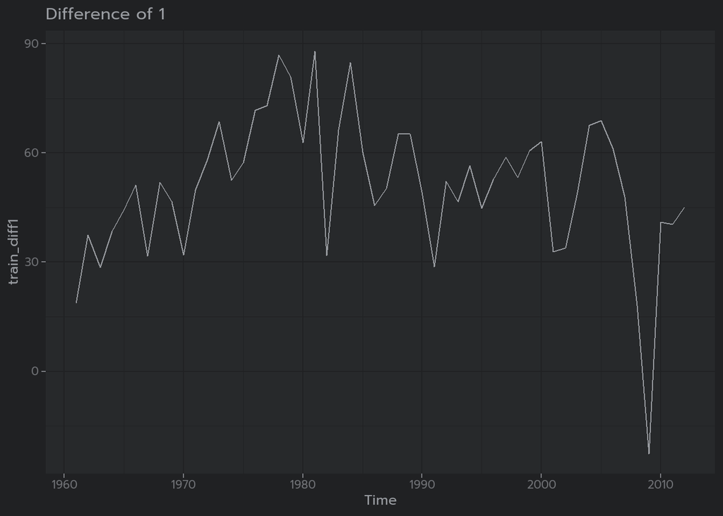

```r
train_diff1 <- diff(train_bc, differences = 1)
train_diff2 <- diff(train_bc, differences = 2)

autoplot(train_diff1) + ggtitle("Difference of 1")
```

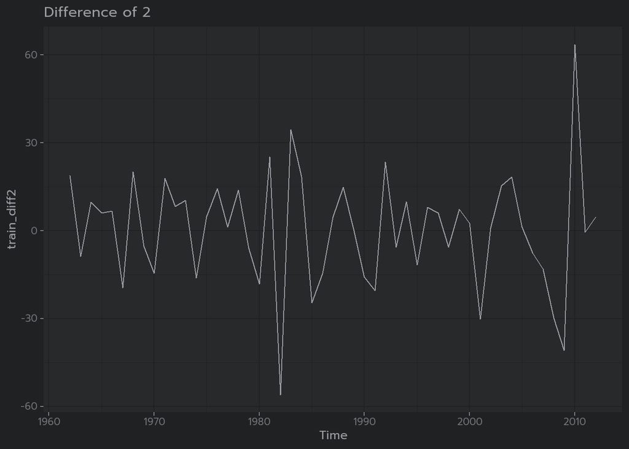

```r
autoplot(train_diff2) + ggtitle("Difference of 2")
```

from the above plots we can observe that the second plot alone looks stationary. Lets use the KPSS test to confirm this.

```r
kpss.test(train_diff1)
```

```
##
##  KPSS Test for Level Stationarity
##
## data:  train_diff1
## KPSS Level = 0.23261, Truncation lag parameter = 3, p-value = 0.1
```

```r
kpss.test(train_diff2)
```

```
##
##  KPSS Test for Level Stationarity
##
## data:  train_diff2
## KPSS Level = 0.10115, Truncation lag parameter = 3, p-value = 0.1
```

Based on the KPSS result, its evident that both the difference of 1 and 2 are stationary. But we will use the difference of 2 as it is more stationary than the difference of 1.

### Question 4:

Fit a suitable ARIMA model to the training dataset using the auto.arima() function. Remember to transform the data first, if necessary, by setting the 𝑙𝑎𝑚𝑏𝑑𝑎 argument. Report the resulting $p$, $d$, $q$ and the coefficients values.

Ans:

#### ARIMA with lambda set.

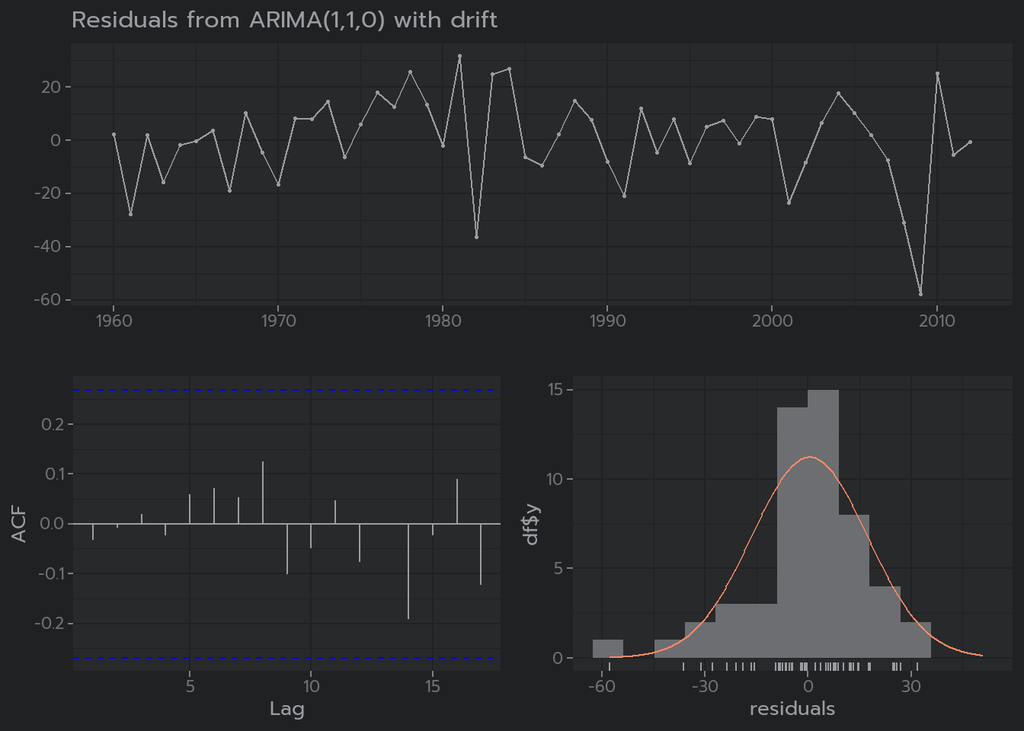

```
##
##  Ljung-Box test
##
## data:  Residuals from ARIMA(1,1,0) with drift
## Q* = 2.7034, df = 9, p-value = 0.9749
##
## Model df: 1.   Total lags used: 10
```

```r
#fitting an arima model
arima_lambda <- auto.arima(train, seasonal = FALSE, lambda = lambda ) #nolint
checkresiduals(arima_lambda)
```

```r
arima_lambda
```

```
## Series: train
## ARIMA(1,1,0) with drift
## Box Cox transformation: lambda= 0.2310656
##
## Coefficients:
##          ar1    drift
##       0.4728  50.3366
## s.e.  0.1242   4.3713
##
## sigma^2 = 295.7:  log likelihood = -220.81
## AIC=447.62   AICc=448.12   BIC=453.47
```

#### ARIMA with box cox transformation

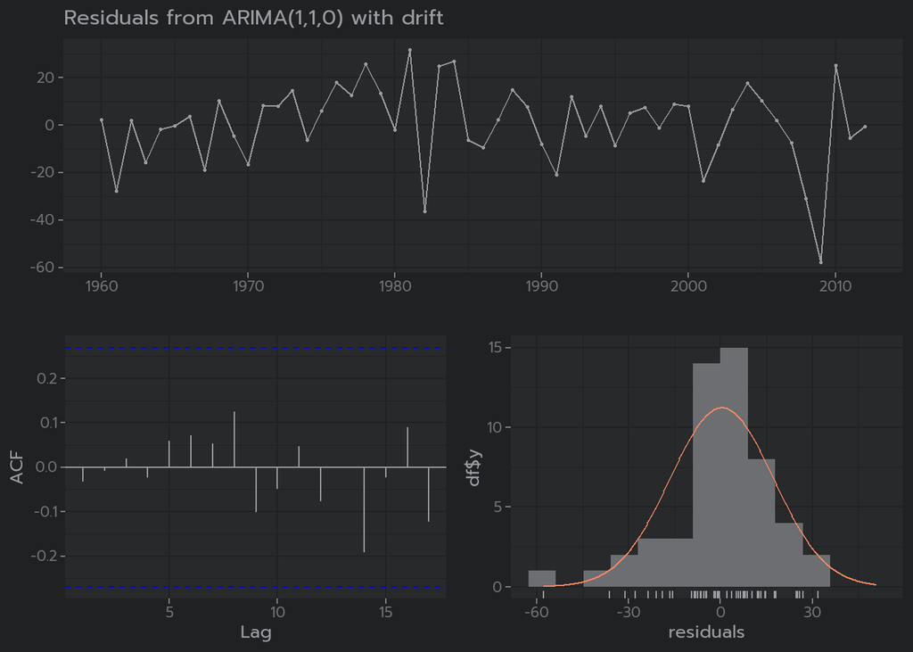

```
##
##  Ljung-Box test
##
## data:  Residuals from ARIMA(1,1,0) with drift
## Q* = 2.7034, df = 9, p-value = 0.9749
##
## Model df: 1.   Total lags used: 10
```

```r
#fitting an arima model
arima_bc <- auto.arima(train_bc, seasonal = FALSE) #nolint
checkresiduals(arima_bc)
```

```r
arima_bc
```

```
## Series: train_bc
## ARIMA(1,1,0) with drift
##
## Coefficients:
##          ar1    drift
##       0.4728  50.3366
## s.e.  0.1242   4.3713
##
## sigma^2 = 295.7:  log likelihood = -220.81
## AIC=447.62   AICc=448.12   BIC=453.47
```

#### ARIMA with box cox transformation and second order difference

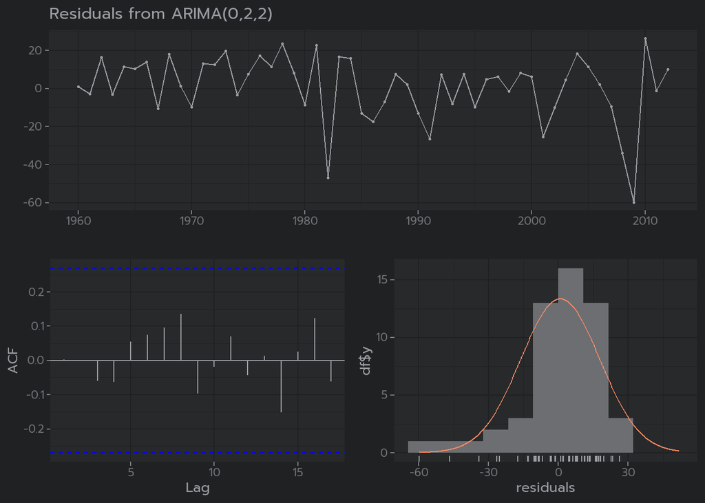

```
##
##  Ljung-Box test
##
## data:  Residuals from ARIMA(0,2,2)
## Q* = 3.393, df = 8, p-value = 0.9073
##
## Model df: 2.   Total lags used: 10
```

```r
#fitting an arima model
arima_bc_2 <- auto.arima(train_bc, seasonal = FALSE,d=2) #nolint
checkresiduals(arima_bc_2)
```

```r
arima_bc_2
```

```
## Series: train_bc
## ARIMA(0,2,2)
##
## Coefficients:
##           ma1      ma2
##       -0.4938  -0.2277
## s.e.   0.1379   0.1343
##
## sigma^2 = 309.5:  log likelihood = -217.88
## AIC=441.77   AICc=442.28   BIC=447.56
```

We can see that the ARIMA(0,2,2) model has a lower AIC, BIC and AICc values compared to the ARIMA(1,1,0) model. This indicates a better goodness of fit. The coefficients of the ARIMA(0,2,2) model are as follows: $p=0, d=2, q=2$

```r
arima_bc_2$coef
```

```
##        ma1        ma2
## -0.4938055 -0.2276681
```

### Question 5:

Compute the sample Extended ACF (EACF) and use the Arima() function to try some other plausible models by experimenting with the orders chosen. Limit your models to 𝑞, 𝑝 ≤ 2 and 𝑑 ≤ 2. Use the model summary() function to compare the Corrected Akaike information criterion (i.e., AICc) values (Note: Smaller values indicated better models).

Ans:

#### No Differencing

```r
eacf(train_bc, ar.max = 2, ma.max = 2)
```

```
## AR/MA
##   0 1 2
## 0 x x x
## 1 x o o
## 2 o o o
```

When using the EACF table, the aim is to use the corners to calculate the ARIMA values. As I is always 0 for no differencing, the AR/MA combinations are ARIMA(2,0,0), ARIMA(1,0,1), ARIMA(1,0,2) and ARIMA(2,0,2).

```r
summary(Arima(train_bc, order = c(2, 0, 0)))$aicc
```

```
## [1] 482.4182
```

```r
summary(Arima(train_bc, order = c(2, 0, 2)))$aicc
```

```
## [1] 477.4339
```

```r
summary(Arima(train_bc, order = c(1, 0, 2)))$aicc
```

```
## [1] 689.26
```

```r
summary(Arima(train_bc, order = c(1, 0, 1)))$aicc
```

```
## [1] 551.1682
```

#### First order differencing

```r
eacf(diff(train_bc), ar.max = 2, ma.max = 2)
```

```
## AR/MA
##   0 1 2
## 0 x o o
## 1 o o o
## 2 x o o
```

As I is always 1 for first order differencing, the AR/MA combinations are ARIMA(1,1,0), ARIMA(1,1,1), ARIMA(1,1,2) and ARIMA(2,1,1). The other values are not taken as they are not corners.

```r
summary(Arima(train_bc, order = c(1, 1, 0)))$aicc
```

```
## [1] 460.991
```

```r
summary(Arima(train_bc, order = c(1, 1, 1)))$aicc
```

```
## [1] 455.0258
```

```r
summary(Arima(train_bc, order = c(1, 1, 2)))$aicc
```

```
## [1] 454.6279
```

```r
summary(Arima(train_bc, order = c(2, 1, 1)))$aicc
```

```
## [1] 454.9093
```

#### Second order differencing

```r
eacf(diff(train_bc, differences = 2), ar.max = 2, ma.max = 2)
```

```
## AR/MA
##   0 1 2
## 0 o o o
## 1 x o o
## 2 x o o
```

```r
summary(Arima(train_bc, order = c(0, 2, 0)))$aicc
```

```
## [1] 450.2887
```

```r
summary(Arima(train_bc, order = c(0, 2, 1)))$aicc
```

```
## [1] 442.8978
```

```r
summary(Arima(train_bc, order = c(0, 2, 2)))$aicc
```

```
## [1] 442.2767
```

```r
summary(Arima(train_bc, order = c(1, 2, 1)))$aicc
```

```
## [1] 442.5009
```

As we can see, the values for ARIMA(0,2,2) is the lowest. This is the same as the model we got from the auto.arima() function.